# Visual Analytics on a Motor Insurance Portfolio

Take-home Exercise 1 · Executive Summary

Jedidiah Asaf

2026-05-24

# Visual Analytics on a Motor Insurance Portfolio

Take-home Exercise 1 · Executive Summary Jedidiah Asaf · 24 May 2026

## Contents

1. Context & objectives
2. Data overview and wrangling
3. Univariate analysis — numerical variables
4. Univariate analysis — portfolio mix
5. Profitability — loss ratio trend
6. Profitability — policy type
7. Profitability — behavioural drivers
8. Profitability — heatmap & brand
9. Volatility — severity distribution
10. Volatility — loss concentration
11. Statistical validation
12. Synthesis & recommendations
13. References

## Context & objectives

> “Insurers often carry underperforming portfolios where the root causes of poor profitability and high volatility are unknown.”
- **Data**: open-access Spanish motor portfolio, 354,140 policy-years, 47 variables, 2022–2024
- **Stack**: tidyverse + ggplot2 family (ggridges, ggdist, ggstatsplot, patchwork)
- **Goal**: visually identify and statistically validate drivers of underperformance

## Data overview & wrangling

[output not shown]

## Univariate — numerical variables

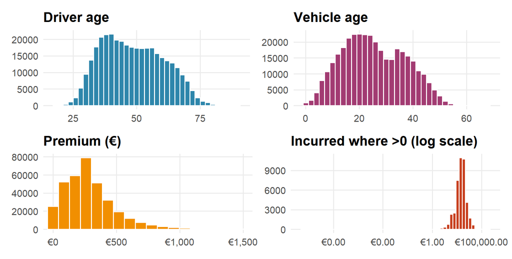

Figure 1

## Univariate — portfolio mix

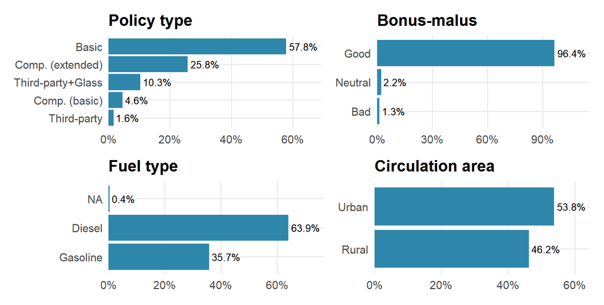

Figure 2

## Profitability — loss ratio is deteriorating

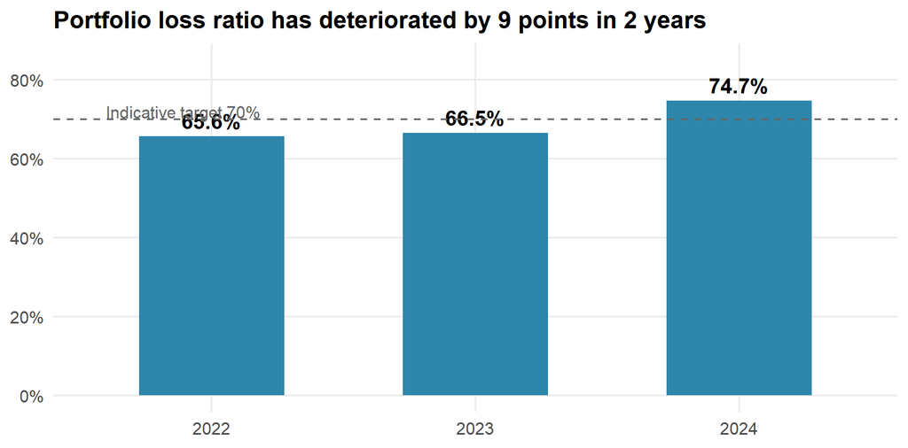

Figure 3

## Profitability — Comp. (basic) is the prime driver

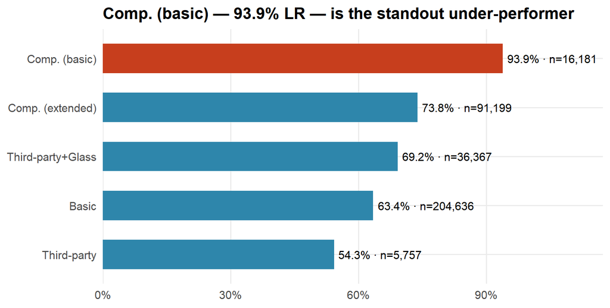

Figure 4

## Profitability — behavioural drivers

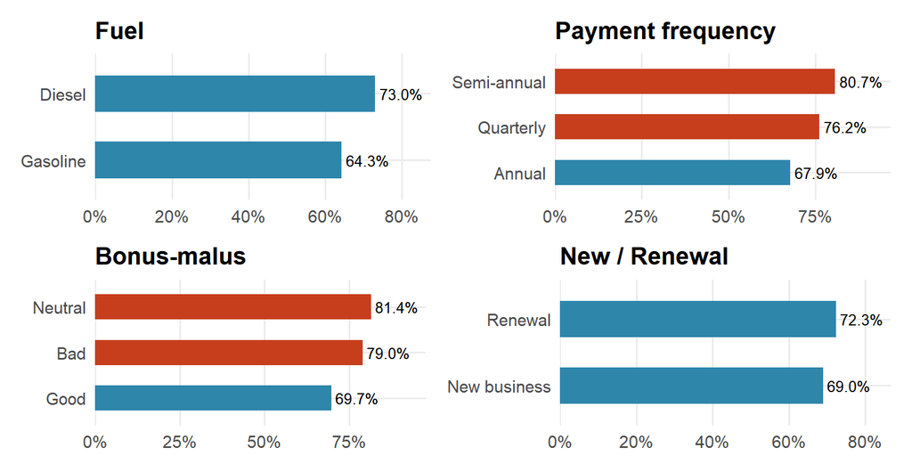

Figure 5

## Profitability — heatmap & brand

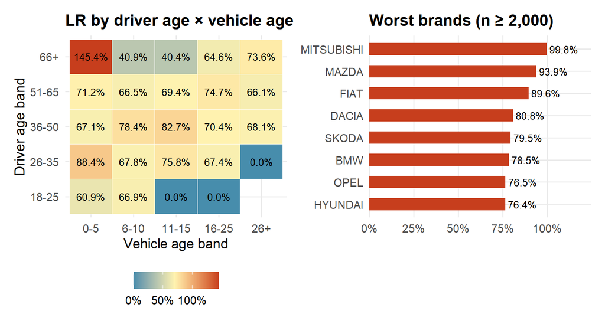

Figure 6

## Volatility — claim severity is long-tailed

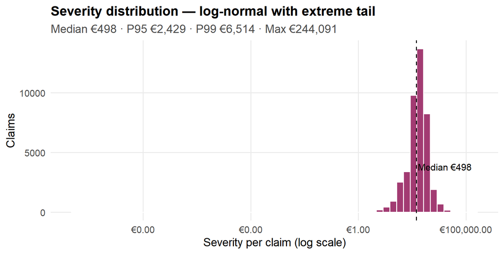

Figure 7

## Volatility — losses are extraordinarily concentrated

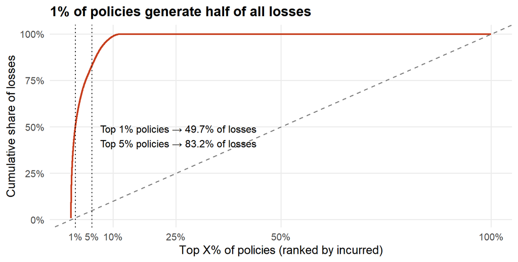

Figure 8

## Statistical validation

Chi-square: claim occurrence vs. categorical drivers

| Variable | Chi-sq | df | p-value | Cramer's V |
| --- | --- | --- | --- | --- |
| policy_type | 6638.4 | 4 | <1e-300 | 0.137 |
| fuel_type | 817.1 | 1 | 1e-179 | 0.048 |
| circulation_area | 225.9 | 1 | 4.7e-51 | 0.025 |
| bonus_score | 297.2 | 2 | 2.9e-65 | 0.029 |
| payment_frequency | 463.9 | 2 | 1.8e-101 | 0.036 |
| business_type | 2317.9 | 1 | <1e-300 | 0.081 |

Kruskal-Wallis on log severity by policy type: H = 1,241, p < 10⁻²⁶⁰.

## Synthesis & recommendations

- **Re-price Comp. (basic)** — single biggest profitability lever (93.9% LR)
- **Add fuel type as a rating factor** — 9-point gap, statistically robust
- **Differentiate by payment frequency** — adverse selection signal worth ~12 points
- **Widen the bonus-malus scale** — 96% in “Good” is too coarse
- **Build a tail-aware monitoring dashboard** — track P95 and P99 of severity, not just the mean

## References

- Quesada-Molina, J.J. et al. — *Spanish motor insurance portfolio dataset*. Mendeley Data.
- Wickham, H. — *ggplot2: Elegant Graphics for Data Analysis* (3rd ed.).
- Patil, I. (2021). *ggstatsplot: Based plots with statistical details*. JOSS, 6(61), 3167.
- Wilke, C.O. — *Fundamentals of Data Visualization*.
- McKinsey & Co. — *Advanced analytics: unlocking new frontiers in P&C insurance*.

Thank you · Questions welcome